# Assignment 3 - Social Network Analysis

Xingyi Xie

2020/10/10

## Part I

Start by installing the “igraph” package. Once you have installed igraph, load the package.

Now upload the data file “comment-data.csv” as a data frame called “D1”. Each row represents a comment from one student to another so the first line shows that student “28” commented on the comment of student “21”. It also shows the gender of both students and the students’ main elective field of study (“major”").

```r
D1 <- read.csv("comment-data.csv", header = TRUE)
```

Before you proceed, you will need to change the data type of the student id variable. Since it is a number R will automatically think it is an integer and code it as such (look at the list of variables by clicking on the data frame arrow in the Data pane. Here you will see the letters “int”" next to the stid variable, that stands for integer). However, in this case we are treating the variable as a category, there is no numeric meaning in the variable. So we need to change the format to be a category, what R calls a “factor”. We can do this with the following code:

```r
D1$comment.to <- as.factor(D1$comment.to)
D1$comment.from <- as.factor(D1$comment.from)
```

igraph requires data to be in a particular structure. There are several structures that it can use but we will be using a combination of an “edge list” and a “vertex list” in this assignment. As you might imagine the edge list contains a list of all the relationships between students and any characteristics of those edges that we might be interested in. There are two essential variables in the edge list a “from” variable and a “to” variable that descibe the relationships between vertices. While the vertex list contains all the characteristics of those vertices, in our case gender and major.

So let’s convert our data into an edge list!

First we will isolate the variables that are of interest: comment.from and comment.to

```r
library(dplyr)

D2 <- select(D1, comment.to, comment.from) #select() chooses the columns
```

Since our data represnts every time a student makes a comment there are multiple rows when the same student comments more than once on another student’s video. We want to collapse these into a single row, with a variable that shows how many times a student-student pair appears.

```r
EDGE <- count(D2, comment.to, comment.from)

names(EDGE) <- c("from", "to", "count")
```

EDGE is your edge list. Now we need to make the vertex list, a list of all the students and their characteristics in our network. Because there are some students who only recieve comments and do not give any we will need to combine the comment.from and comment.to variables to produce a complete list.

```r
#First we will separate the commenters from our commentees
V.FROM <- select(D1, comment.from, from.gender, from.major)

#Now we will separate the commentees from our commenters
V.TO <- select(D1, comment.to, to.gender, to.major)

#Make sure that the from and to data frames have the same variables names
names(V.FROM) <- c("id", "gender.from", "major.from")
names(V.TO) <- c("id", "gender.to", "major.to")

#Make sure that the id variable in both dataframes has the same number of levels
lvls <- sort(union(levels(V.FROM$id), levels(V.TO$id)))

VERTEX <- full_join(mutate(V.FROM, id=factor(id, levels=lvls)),
    mutate(V.TO, id=factor(id, levels=lvls)), by = "id")

#Fill in missing gender and major values - ifelse() will convert factors to numerical values so convert to character
VERTEX$gender.from <- ifelse(is.na(VERTEX$gender.from) == TRUE, as.factor(as.character(VERTEX$gender.to)), as.factor(as.character(VERTEX$gender.from)))

VERTEX$major.from <- ifelse(is.na(VERTEX$major.from) == TRUE, as.factor(as.character(VERTEX$major.to)), as.factor(as.character(VERTEX$major.from)))

#Remove redundant gender and major variables
VERTEX <- select(VERTEX, id, gender.from, major.from)

#rename variables
names(VERTEX) <- c("id", "gender", "major")

#Remove all the repeats so that we just have a list of each student and their characteristics
VERTEX <- unique(VERTEX)
```

Now we have both a Vertex and Edge list it is time to plot our graph!

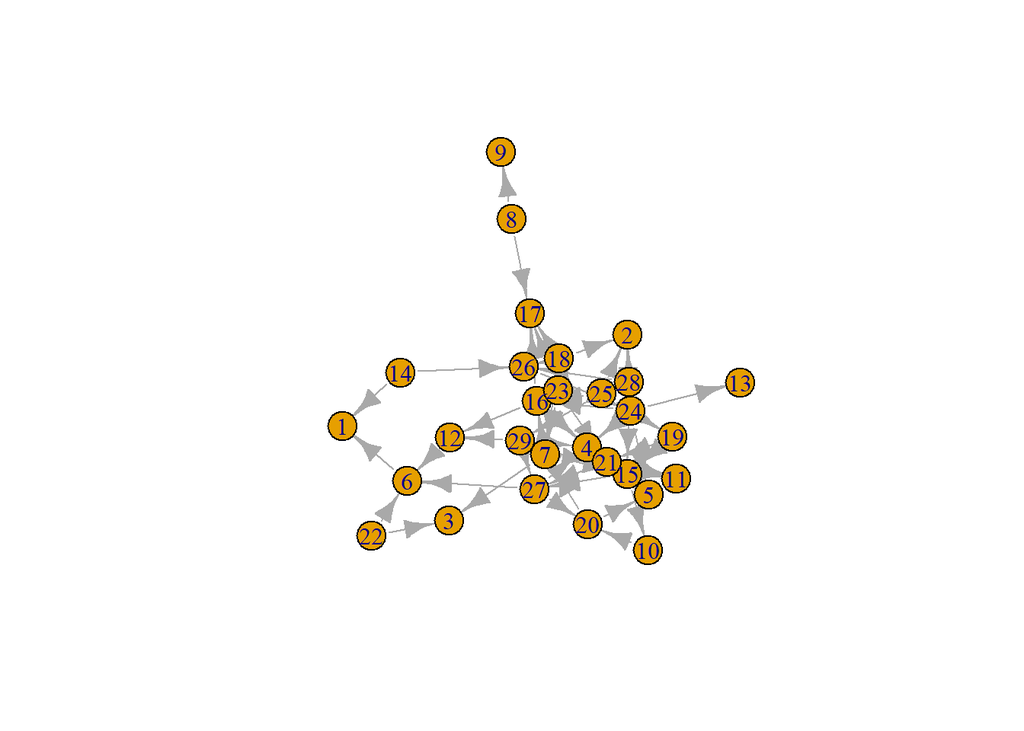

```r
#Load the igraph package

library(igraph)

#First we will make an object that contains the graph information using our two dataframes EDGE and VERTEX. Notice that we have made "directed = TRUE" - our graph is directed since comments are being given from one student to another.

g <- graph.data.frame(EDGE, directed=TRUE, vertices=VERTEX)

#Now we can plot our graph using the force directed graphing technique - our old friend Fruchertman-Reingold!

plot(g,layout=layout.fruchterman.reingold)
```

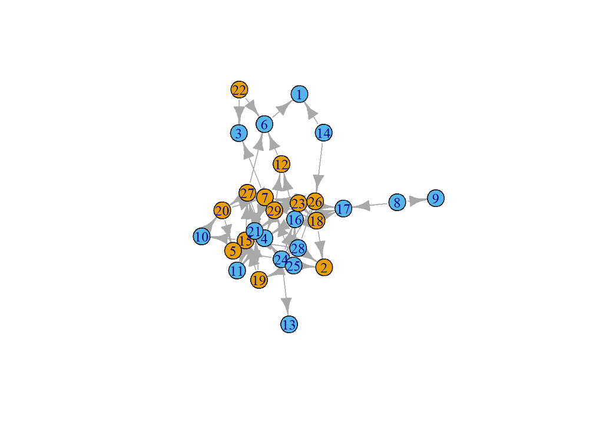

```r
#There are many ways to change the attributes of the graph to represent different characteristics of the newtork. For example, we can color the nodes according to gender.

plot(g,layout=layout.fruchterman.reingold, vertex.color=VERTEX$gender)
```

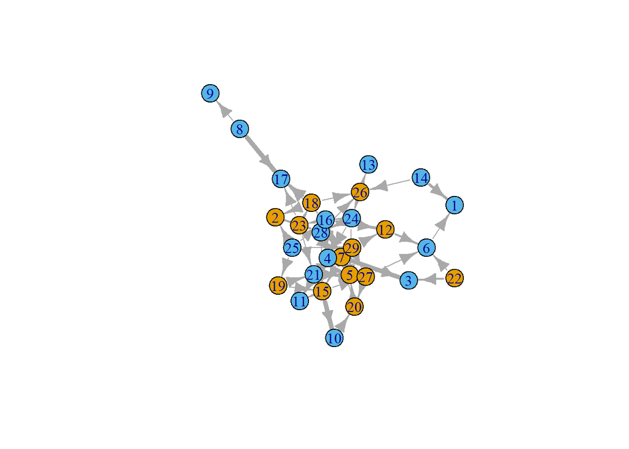

```r
#We can change the thickness of the edge according to the number of times a particular student has sent another student a comment.

plot(g,layout=layout.fruchterman.reingold, vertex.color=VERTEX$gender, edge.width=EDGE$count)
```

## Part II

In Part II your task is to [look up](http://igraph.org/r/) in the igraph documentation and modify the graph above so that:

- Ensure that sizing allows for an unobstructed view of the network features (For example, the arrow size is smaller)
- The vertices are colored according to major
- The vertices are sized according to the number of comments they have recieved

```r
#Load the igraph package
library(igraph)
g <- graph.data.frame(EDGE, directed=TRUE, vertices=VERTEX)
class(g)
```

```
## [1] "igraph"
```

```r
vertex.attributes(g)
```

```
## $name
##  [1] "3"  "28" "6"  "11" "15" "17" "7"  "5"  "16" "10" "27" "4"  "2"  "20" "26"
## [16] "13" "19" "21" "1"  "24" "23" "29" "18" "12" "9"  "22" "25" "8"  "14"
##
## $gender
##  [1] 2 2 2 2 1 2 1 1 2 2 1 2 1 1 1 2 1 2 2 2 1 1 1 1 2 1 2 2 2
##
## $major
##  [1] 2 4 3 3 4 4 4 3 2 2 4 2 4 2 2 4 3 4 1 2 1 3 3 4 4 2 2 1 3
```

```r
edge.attributes(g)
```

```
## $count
##  [1] 1 1 5 1 1 1 1 5 1 2 3 1 5 1 1 1 3 1 1 1 1 3 1 1 1 1 1 2 1 3 2 1 1 1 1 1 1 1
## [39] 1 1 1 1 1 1 1 1 2 1 2 2 1 1 1 1 1 1
```

```r
summary(g)
```

```
## IGRAPH aa45de5 DN-- 29 56 --
## + attr: name (v/c), gender (v/n), major (v/n), count (e/n)
```

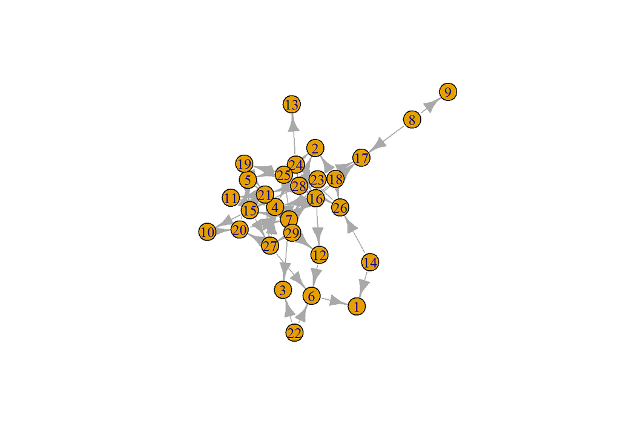

```r
g1 <- igraph::graph_from_data_frame(d= EDGE,vertices = VERTEX, directed = T)
plot(g1)

# isolated nodes
detach(package:igraph)
library(statnet)
```

```r
library(intergraph)
g2 <- asNetwork(g1)
length(isolates(g2))
```

```
## [1] 0
```

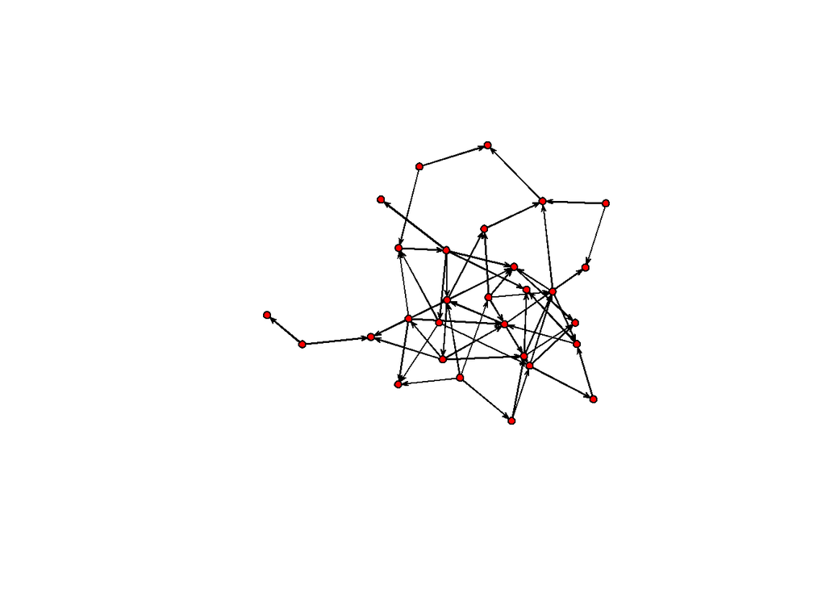

```r
plot(g2)
```

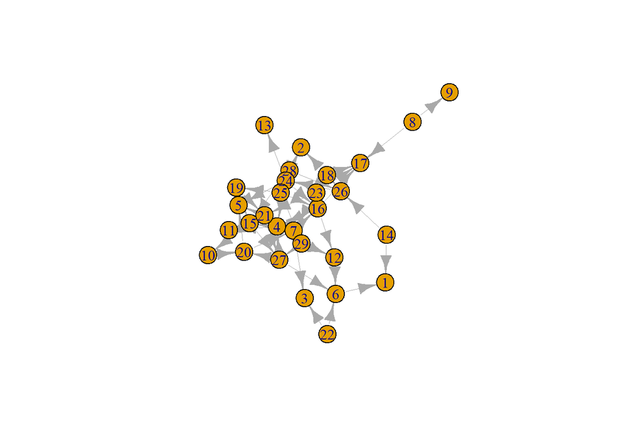

```r
plot(g,edge.width=0.1)
```

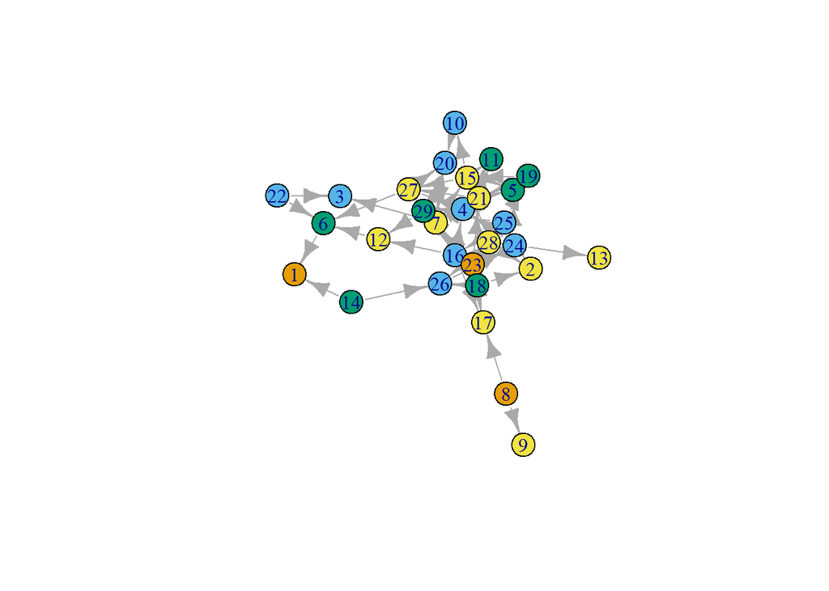

```r
plot(g,vertex.color=VERTEX$major,edge.size=0.01)
```

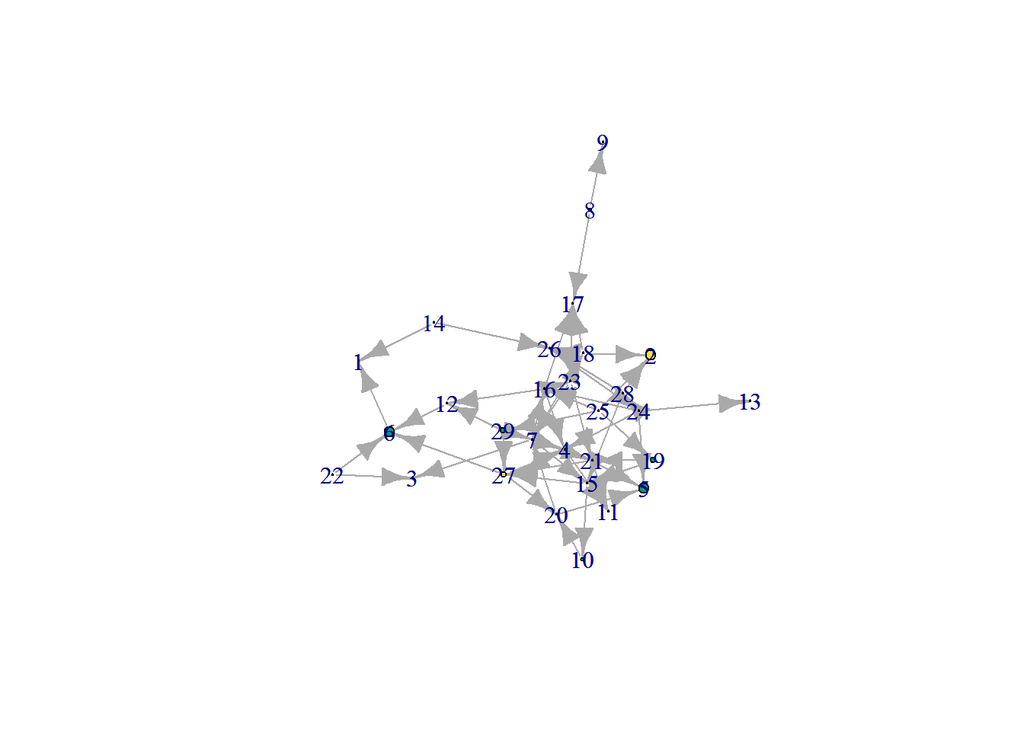

```r
plot(g,edge.size=0.1,vertex.color=VERTEX$major,vertex.size=EDGE$count)
```

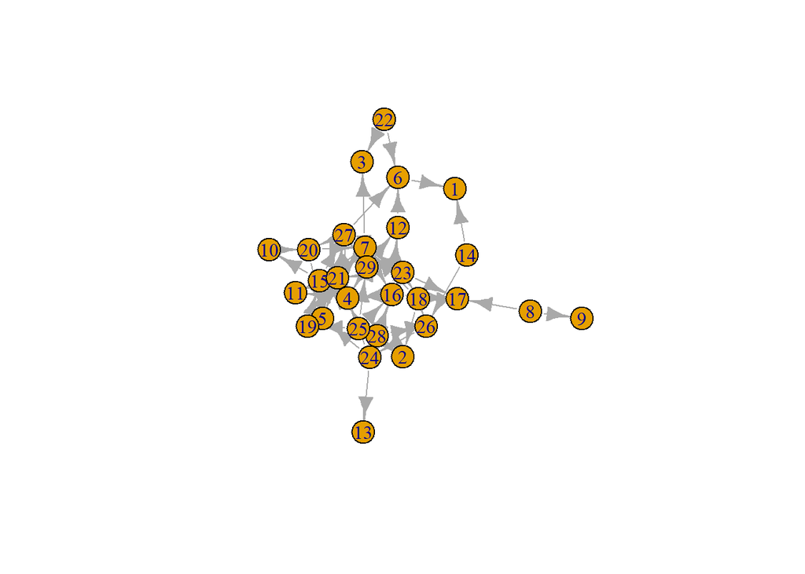

```r
g %>%
  plot()
```

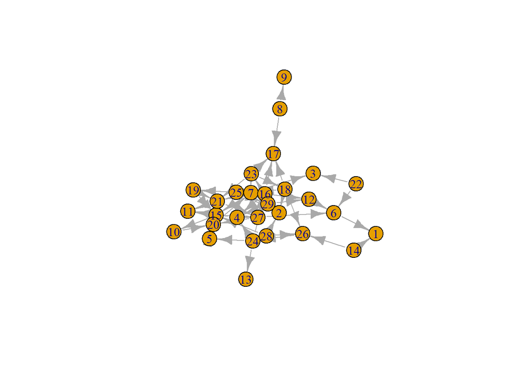

```r
g1 %>%
  plot()
```

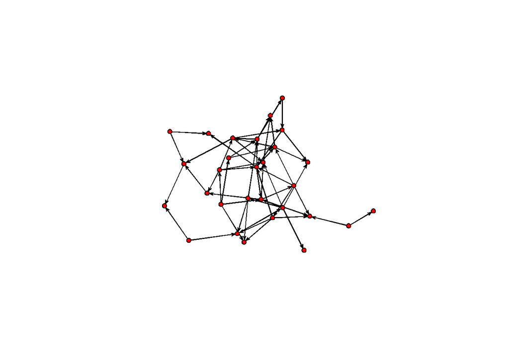

```r
plot(g2)
```

```r
degree(g2)
```

```
##  [1] 2 4 4 3 6 4 8 3 7 2 6 5 3 4 4 1 3 6 2 6 5 5 5 3 1 2 4 2 2
```

```r
closeness(g2)
```

```
##  [1] 0 0 0 0 0 0 0 0 0 0 0 0 0 0 0 0 0 0 0 0 0 0 0 0 0 0 0 0 0
```

```r
# Betweenness centrality
# B(ni) = ΣG(jk)(ni)/G(jk)
# where G(jk) is the geodesic between nodes j and k.
# G(jk)(ni) is the number of geodesics between nodes j and k that contain node i.
betweenness(g2)
```

```
##  [1]   0.000000  16.000000  17.000000   0.000000  47.583333   0.000000
##  [7] 127.666667   0.000000 119.916667  15.833333  61.333333   6.500000
## [13]   0.000000  79.166667  65.833333   0.000000   4.500000  27.916667
## [19]   0.000000  71.833333  80.333333   6.583333  54.000000  12.000000
## [25]   0.000000   0.000000   0.000000   0.000000   0.000000
```

```r
####Model
Network_model <- ergm(g2 ~ edges +
                                nodefactor("gender")+
                                nodefactor("major"))
summary(Network_model)
```

```
##
## ==========================
## Summary of model fit
## ==========================
##
## Formula:   g2 ~ edges + nodefactor("gender") + nodefactor("major")
##
## Iterations:  5 out of 20
##
## Monte Carlo MLE Results:
##                     Estimate Std. Error MCMC % z value Pr(>|z|)
## edges                -2.8016     0.7256      0  -3.861 0.000113 ***
## nodefactor.gender.2  -0.2801     0.2043      0  -1.371 0.170403
## nodefactor.major.2    0.3179     0.3903      0   0.815 0.415333
## nodefactor.major.3    0.1243     0.4096      0   0.304 0.761474
## nodefactor.major.4    0.3254     0.3863      0   0.842 0.399542
## ---
## Signif. codes:  0 '***' 0.001 '**' 0.01 '*' 0.05 '.' 0.1 ' ' 1
##
##      Null Deviance: 1125.7  on 812  degrees of freedom
##  Residual Deviance:  404.4  on 807  degrees of freedom
##
## AIC: 414.4    BIC: 437.9    (Smaller is better.)
```

## Part III

Now practice with data from our class. This data is real class data directly exported from Qualtrics and you will need to wrangle it into shape before you can work with it. Import it into R as a data frame and look at it carefully to identify problems.

Please create a **person-network** with the data set hudk4050-classes.csv. To create this network you will need to create a person-class matrix using the tidyr functions and then create a person-person matrix using `t()`. You will then need to plot a matrix rather than a to/from data frame using igraph.

Once you have done this, also [look up](http://igraph.org/r/) how to generate the following network metrics:

- Betweeness centrality and dregree centrality. **Who is the most central person in the network according to these two metrics? Write a sentence or two that describes your interpretation of these metrics**
- Color the nodes according to interest. Are there any clusters of interest that correspond to clusters in the network? Write a sentence or two describing your interpetation.

```r
dd1 <- read.csv("hudk4050-classes.csv", stringsAsFactors = FALSE, header= TRUE)
D1 <- dd1
dd1 <- dd1[-1,-2,]
colnames(D1) <- D1[1,]
```

#Data cleaning #transform into long data

```r
library(tidyr)
library(dplyr)
library(stringr)
library(janitor)
D1 <- slice(D1,3:49)
#Remove last column
D1 <- select(D1,1:8)
#Merge name columns
D1 <- unite(D1,"name",`First Name`, `Last Name`, sep="")
#Remove unpredictable characters from names
D1$name <- str_replace(D1$name, "`", "")
#Make all name captalized first letters only
D1$name <- str_to_title(D1$name)
#Make all class letters capitals
D1 <- D1 %>% mutate_at(2:7, list(toupper))
#Remove whitespace between letters and numbers in class
D1 <- D1 %>% mutate_at(2:7, str_replace_all, " ", "")
```

# Data restructuring

```r
# Create a dataframe with two variables, student and class
D2 <- D1 %>%gather(labe, class, 2:7, na.rm = TRUE, convert = FALSE) %>% select(name, class)
#Create a new variable containing 1s that will become our counts
D3 <- D2 %>% tabyl(name,class)
rownames(D3) <- D3$name
D3 <- select(D3, -name, -HUDK4050)
```

#Matrix operations

```r
#Convert to matrix
D3 <- as.matrix(D3)
#Create person-person matrix
D3 <- D3 %*% t(D3)
```

#Graphing

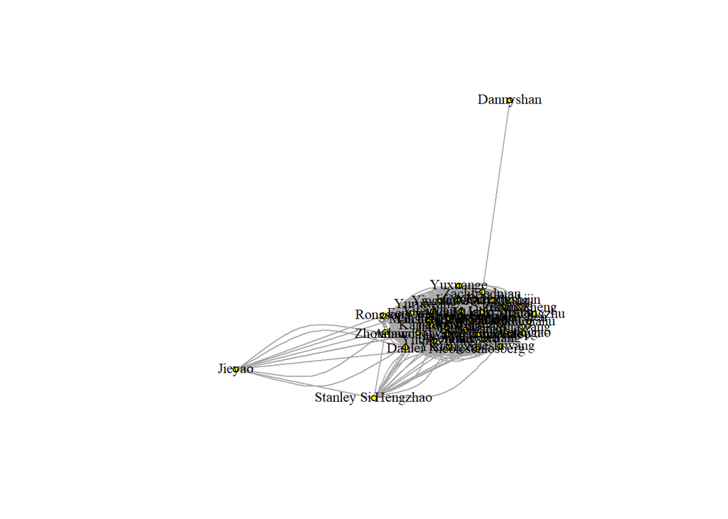

```r
library(igraph)
g <- graph.adjacency(D3, mode="undirected", diag = FALSE)
plot(g,layout=layout.fruchterman.reingold,
     vertex.size = 4,
     vertex.label.cex =0.8,
     vertex.label.color="black",
     vertex.color="yellow")
```

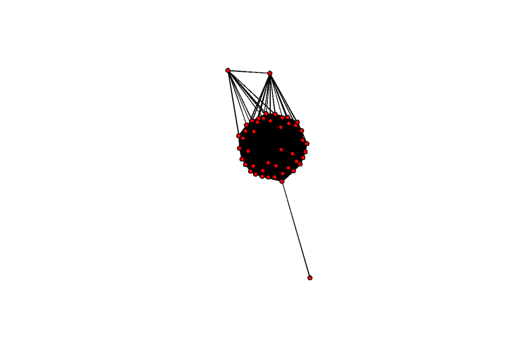

```r
Network <- g %>%
                 simplify(remove.multiple = TRUE,remove.loops = TRUE) %>%
                 delete.vertices(.,which(degree(.)==0)) %>%
                 intergraph::asNetwork()

plot(Network)
```

```r
# degree centrality
degree(g)
```

```
## Abdul Malik Muftau         Ali Al Jabri      Amandaoliveira           Berjakian
##                 452                 452                 236                 461
##            Chriskim              Danlei           Dannyshan           Fangqiliu
##                 560                 132                   1                 453
##             Feiwang          Guoliangxu          Hangshijin             He Chen
##                 236                 261                 261                 342
##          Hyungoolee            Jiaao Qi          Jiacongzhu          Jiahaoshen
##                 343                 261                 261                 261
##          Jiashengyu              Jieyao         Kaijie Fang  Mahshaddavoodifard
##                 458                  11                 351                 452
##    Nicoleschlosberg         Qianhuiyuan            Rongsang         Ruoyi Zhang
##                 240                 560                 124                 464
##         Saravasquez        Shuyingxiong Stanley Si Hengzhao         Tianyuchang
##                 560                 343                  19                 354
##       Vidyamadhavan         Wenningxiao            Wenqigao          Xiaojialiu
##                 560                 346                 261                 252
##           Xijiawang         Xiyun Zhang          Xueshiwang          Yifeizhang
##                 242                 261                 244                 254
##          Yingxinxie           Yingxinye           Yixiongxu          Yuchengpan
##                 261                 232                 240                 349
##           Yunzhaowu           Yuruiwang          Yutingzhou            Yuxuange
##                 242                 230                 246                 138
##        Zachfriedman        Zhixin Zheng            Zhoudawu
##                 241                 250                 130
```

```r
# Closeness centrality
# The inverse of the sum of all the distances between node i and all the other nodes in the network.
closeness(g)
```

```
## Abdul Malik Muftau         Ali Al Jabri      Amandaoliveira           Berjakian
##          0.02040816          0.02040816          0.02127660          0.02083333
##            Chriskim              Danlei           Dannyshan           Fangqiliu
##          0.02040816          0.02127660          0.01075269          0.02040816
##             Feiwang          Guoliangxu          Hangshijin             He Chen
##          0.02083333          0.02040816          0.02040816          0.02040816
##          Hyungoolee            Jiaao Qi          Jiacongzhu          Jiahaoshen
##          0.02040816          0.02040816          0.02040816          0.02040816
##          Jiashengyu              Jieyao         Kaijie Fang  Mahshaddavoodifard
##          0.02127660          0.01190476          0.02083333          0.02040816
##    Nicoleschlosberg         Qianhuiyuan            Rongsang         Ruoyi Zhang
##          0.02083333          0.02040816          0.02083333          0.02040816
##         Saravasquez        Shuyingxiong Stanley Si Hengzhao         Tianyuchang
##          0.02040816          0.02040816          0.01298701          0.02083333
##       Vidyamadhavan         Wenningxiao            Wenqigao          Xiaojialiu
##          0.02040816          0.02083333          0.02040816          0.02040816
##           Xijiawang         Xiyun Zhang          Xueshiwang          Yifeizhang
##          0.02040816          0.02040816          0.02083333          0.02083333
##          Yingxinxie           Yingxinye           Yixiongxu          Yuchengpan
##          0.02040816          0.02040816          0.02127660          0.02127660
##           Yunzhaowu           Yuruiwang          Yutingzhou            Yuxuange
##          0.02083333          0.02040816          0.02083333          0.02040816
##        Zachfriedman        Zhixin Zheng            Zhoudawu
##          0.02083333          0.02040816          0.02127660
```

```r
# Betweenness centrality
# B(ni) = ΣG(jk)(ni)/G(jk)
# where G(jk) is the geodesic between nodes j and k.
# G(jk)(ni) is the number of geodesics between nodes j and k that contain node i.
betweenness(g)
```

```
## Abdul Malik Muftau         Ali Al Jabri      Amandaoliveira           Berjakian
##          0.00000000          0.00000000          5.44828100          2.82468533
##            Chriskim              Danlei           Dannyshan           Fangqiliu
##          0.00000000          5.14222776          0.00000000          0.00000000
##             Feiwang          Guoliangxu          Hangshijin             He Chen
##          4.03593833          0.00000000          0.00000000          0.00000000
##          Hyungoolee            Jiaao Qi          Jiacongzhu          Jiahaoshen
##          0.00000000          0.00000000          0.00000000          0.00000000
##          Jiashengyu              Jieyao         Kaijie Fang  Mahshaddavoodifard
##         10.89656199          0.03219697          2.11851400          0.00000000
##    Nicoleschlosberg         Qianhuiyuan            Rongsang         Ruoyi Zhang
##          1.43587208          0.00000000          2.01796916          0.00000000
##         Saravasquez        Shuyingxiong Stanley Si Hengzhao         Tianyuchang
##          0.00000000          0.00000000          0.23960081          2.11851400
##       Vidyamadhavan         Wenningxiao            Wenqigao          Xiaojialiu
##          0.00000000          2.11851400          0.00000000          0.00000000
##           Xijiawang         Xiyun Zhang          Xueshiwang          Yifeizhang
##          0.00000000          0.00000000          2.82468533          1.55916270
##          Yingxinxie           Yingxinye           Yixiongxu          Yuchengpan
##          0.00000000          0.00000000          6.92668057          8.19623102
##           Yunzhaowu           Yuruiwang          Yutingzhou            Yuxuange
##          1.41234267          0.00000000          2.82468533          0.00000000
##        Zachfriedman        Zhixin Zheng            Zhoudawu
##         45.00000000          0.00000000          4.82733694
```

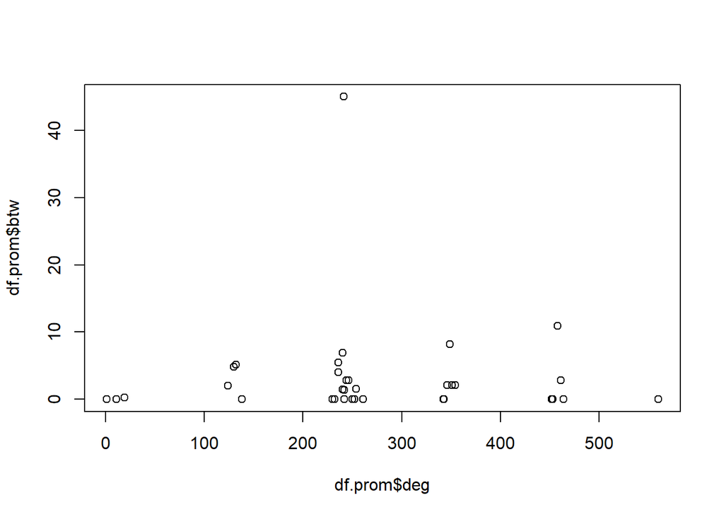

```r
df.prom <- data.frame(
           deg = degree(g),
           cls = closeness(g),
           btw = betweenness(g))
plot(df.prom$deg,df.prom$btw)
```

```r
which(df.prom$deg>500)
```

```
## [1]  5 22 25 29
```

```r
summary(df.prom)
```

```
##       deg             cls               btw
##  Min.   :  1.0   Min.   :0.01075   Min.   : 0.000
##  1st Qu.:240.0   1st Qu.:0.02041   1st Qu.: 0.000
##  Median :261.0   Median :0.02041   Median : 0.000
##  Mean   :295.5   Mean   :0.02008   Mean   : 2.383
##  3rd Qu.:352.5   3rd Qu.:0.02083   3rd Qu.: 2.119
##  Max.   :560.0   Max.   :0.02128   Max.   :45.000
```

```r
which(df.prom$btw>40)
```

```
## [1] 45
```

```r
df.prom[45,]
```

```
##              deg        cls btw
## Zachfriedman 241 0.02083333  45
```

```r
df.prom <- df.prom[-45,]
summary(df.prom)
```

```
##       deg             cls               btw
##  Min.   :  1.0   Min.   :0.01075   Min.   : 0.000
##  1st Qu.:240.0   1st Qu.:0.02041   1st Qu.: 0.000
##  Median :261.0   Median :0.02041   Median : 0.000
##  Mean   :296.7   Mean   :0.02007   Mean   : 1.457
##  3rd Qu.:353.2   3rd Qu.:0.02083   3rd Qu.: 2.119
##  Max.   :560.0   Max.   :0.02128   Max.   :10.897
```

```r
which(df.prom$btw>10)
```

```
## [1] 17
```

```r
df.prom[17,]
```

```
##            deg       cls      btw
## Jiashengyu 458 0.0212766 10.89656
```

### Answer: I think Jia Shengyu is the most central person in the network. She has the second highest betweenness, which is very important.

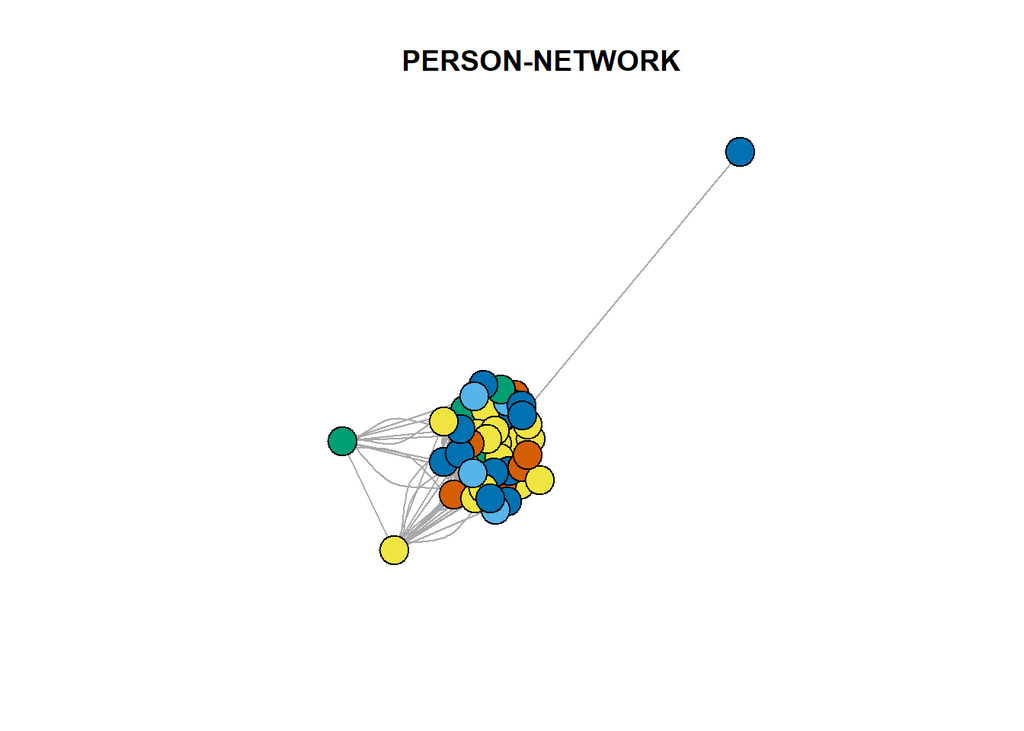

```r
#creating a variable for the number of classes so I can use it as the vertex size
plot(g,vertex.color=factor(dd1$Q18), vertex.label=NA,main="PERSON-NETWORK")
```

#I think common interest has to do with a person’s major and it is likely that students in the same major have the same classes.

### To Submit Your Assignment

Please submit your assignment by first “knitting” your RMarkdown document into an html file and then comit, push and pull request both the RMarkdown file and the html file.